# An Employment Predictor Application

2023-09-28

## Application Data & Purpose

Longley’s Economic Regression Data

- A macroeconomic data set which provides a well-known example for a highly collinear regression.
- A data frame with 7 economic variables, observed yearly from 1947 to 1962

Purpose of application

- A simple and easy to use linear regression model to predict the number of employed for a given population size

## Application Description

- A slider to select a given population size
- A check box to show or hide the regression model
- Real time plot update as population size changes
- A ‘Result’ tab to display results in the form of a scatter plot, and text output
- A ‘Documentation’ tab to provide basic instructions on app usage
- URL to shiny application https://iandobbs.shinyapps.io/longley/
- URL to server.R and ui.R code on github https://github.com/IanDobbs/DDPproject/tree/gh-pages/longley

## The Regression Model

- The regression model `lm(Employed ~ Population, longley)` produces the following coefficients and r-squared values to determine if the explanatory model is a good fit.

```
##              Estimate Std. Error   t value          Pr(>|t|)
## (Intercept) 8.3806742 4.42243393  1.895037 0.078927279361911
## Population  0.4848781 0.03760029 12.895593 0.000000003693245
```

```
## [1] 0.9223501
```

## Residual Plot

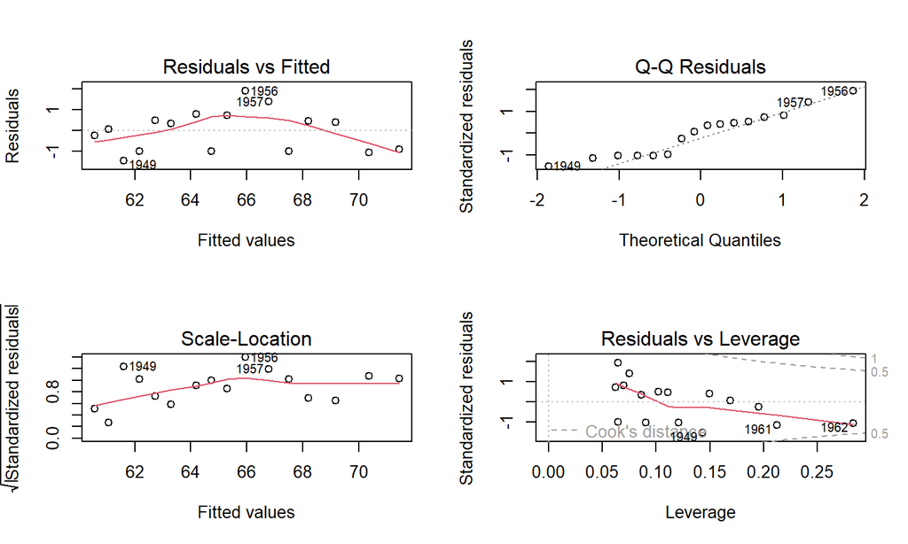